# weekly_report_2025

国内ゲームハード週販レポート (2025-08-24)

- ハードウェアの販売データはファミ通の調査結果を元にしています。
- 一部のデータについては処理の都合上、1週間毎の値にアレンジしています。

## 直近4週間のハード売り上げ／累計推移

今週はSwitch2の落ち込みが目立ちます。お盆期間に売り切って一時的に供給がタイトなだけか、 ZA同梱版の大量出荷に備えて出荷を絞り始めたか判断するには来週を待つ必要があります。 Switch2 200万台は9月中に到達すると思われますが、第何週になるかは出荷次第です。

PS5の累計700万台が迫ってきました。9月頭からセールが始まるので、TGS前に「700万台達成」を アナウンスできるかも知れません。9月の見どころです。

| 報告日 | ハード | 販売数 | 累計 |
| --- | --- | --- | --- |
| 2025-08-03 | Nintendo Switch2 | 62733 | 1677123 |
|  | Nintendo Switch | 18637 | 35869618 |
|  | PlayStation5 | 7141 | 6946379 |
|  | Xbox Series X\|S | 271 | 682066 |
|  | PlayStation4 | 19 | 9490707 |
| 2025-08-10 | Nintendo Switch2 | 89820 | 1766943 |
|  | Nintendo Switch | 18673 | 35888291 |
|  | PlayStation5 | 8565 | 6954944 |
|  | Xbox Series X\|S | 326 | 682392 |
|  | PlayStation4 | 16 | 9490723 |
| 2025-08-17 | Nintendo Switch2 | 89821 | 1856764 |
|  | Nintendo Switch | 18673 | 35906964 |
|  | PlayStation5 | 8566 | 6963510 |
|  | Xbox Series X\|S | 326 | 682718 |
|  | PlayStation4 | 16 | 9490739 |
| 2025-08-24 | Nintendo Switch2 | 35359 | 1892123 |
|  | Nintendo Switch | 17945 | 35924909 |
|  | PlayStation5 | 6428 | 6969938 |
|  | Xbox Series X\|S | 287 | 683005 |
|  | PlayStation4 | 13 | 9490752 |

## 直近8ヶ月の販売推移

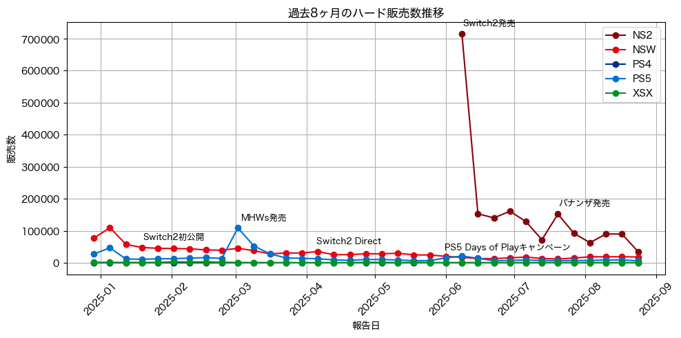

### 直近8ヶ月の販売状況(Switch2を除く）

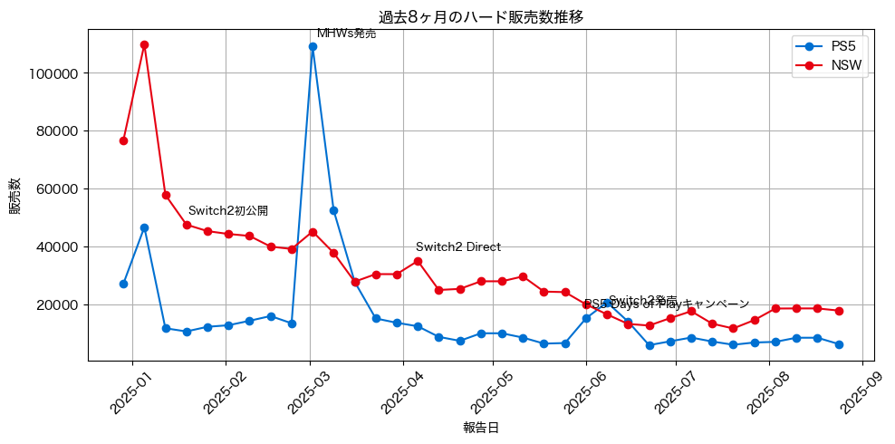

## 累計状況(Switch, PS5, Switch2)

#### 発売日からの累計販売状況

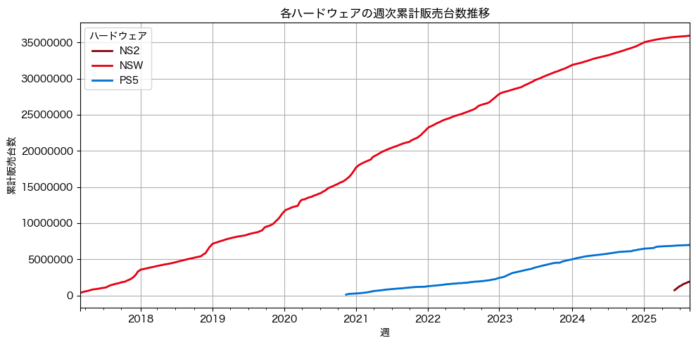

#### 累計販売状況（ロンチ揃え)

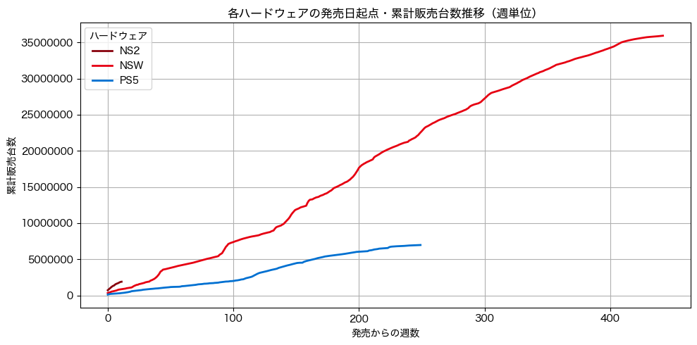

## Switch2販売状況

### 歴代機種との比較

Switch2はGBAに次ぐ歴代2位の初動を維持。3位のDSを引き離しGBAに迫る状況。

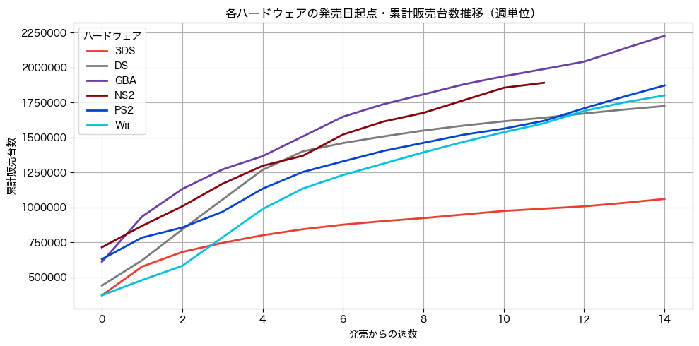

## Switch/Switch2ロンチ比較

ロンチ週以降のSwitchとSwitch2の販売状況の比較です。 実質的にSwitchとSwitch2の国内出荷状況を比較しています。

先週までは、概ね、Switch2はSwitchの2倍以上の出荷を行なってきましたが、 今週は落ち込んでいます。

Switch2の場合は11周目で4万台を切りました。このままZA発売まで抑制された出荷状況が続くのか、 今週の落ち込みが一時的な現象なのか、ここから先の出荷状況に注目です。

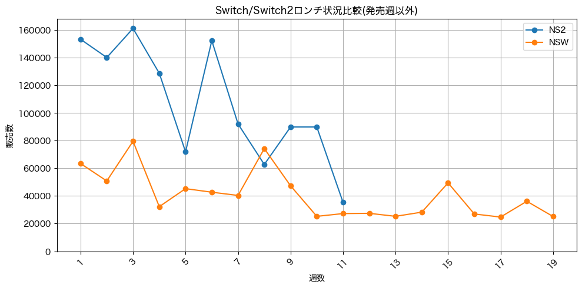

### PS5/Switch2累積台数差

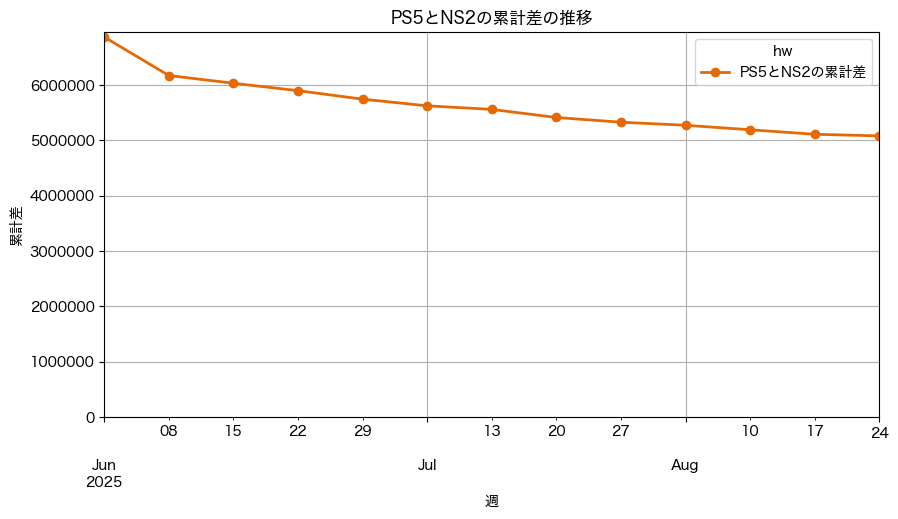

#### 参考:PS4とSwitchとの累計差の推移

[figure not shown]

## ハードメーカーシェア

(2025年のシェアは1月から現時点までの状況です)

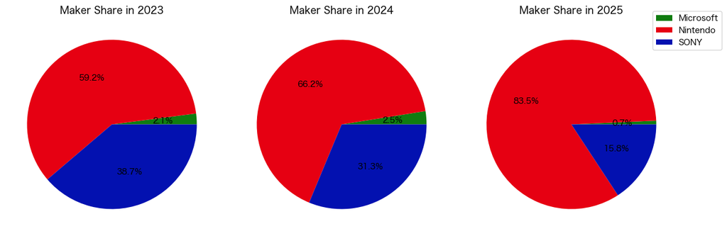